# Intermediate Python for Engineers Day 4

Welcome!

# Setup

Here are some setup instructions:

## Browser

Please use Chrome or Firefox or Safari. *Preferably not IE or Edge*.

## Jupyter notebook server

1. Go to https://hub.pythoncharmers.com/
2. Your username is your email address
3. The password is the same as you used to log in to Zulip and is in the setup email.

## Load up your notebook

- It will be called "Yourname Day 1.ipynb".
- Save it (Control-S or File | Save Notebook).

We'll give more instructions on getting started with the notebooks as we start the course.

## Zulip chat server

1. Go to https://pythoncharmers.zulipchat.com
2. **Test:** Please send a message to our stream (#**485 Python for Engineers** ) saying Hi!

## Resources

- Please download the course materials PDF (in your home folder)
- You may also download the `.zip` file containing the Jupyter Notebooks of the course materials

## Trainer notebook

We suggest that you load up the trainer's notebook from the Trainer folder in a separate browser tab and reload when needed.

(To do this, right-click the file, then choose "Open in New Browser Tab". Then hit F5 or Command-R whenever you want to see the latest version of the trainer's notebook.)

## Session 4: Testing

Session 4 teaches you how to create automated tests for *Python* code:

- Creating scripts with command-line arguments (homework revision)
- Why testing? Overview of test-driven development (TDD)
- Introduction to *pytest*
- Fixtures
- Coverage reports
- Testing best practices
- Introduction to mocking
- (Time permitting): Introduction to property-based testing

Quick side note: our server is configured that it is reset to the base state when you shut down (which it does automatically overnight) - need to pip install again

### Exercise: Running newster as a command line app

1. Once you've got the CLI setup in `__main__.py` set up the console scripts in `setup.py`

```python
entry_points={"console_scripts": ["newster=newster.__main__:main"]}
```

1. Create a new text file that contains 2 URLs - grab one from economist.com and another from your local news source
2. Try and run `newster` from the command line, generating a report from your URLs.

```python
!newster urls.txt report.html
```

If you need to catch up before unit testing feel free to copy Trainer/newster_solution

## Getting started with testing

First, lets run a test:

```python
%%!
cd newster_parent
pytest
```

```
['============================= test session starts ==============================',
 'platform linux -- Python 3.8.4, pytest-6.0.1, py-1.9.0, pluggy-0.13.1',
 'rootdir: /home/jovyan/newster_parent',
 'plugins: Faker-4.1.2, dash-1.15.0, hypothesis-5.29.0, cov-2.10.1',
 'collected 1 item',
 '',
 'tests/test_sample.py .                                                   [100%]',
 '',
 '============================== 1 passed in 0.38s ===============================']
```

Pytest looks for Python modules that either start or finish with "test" - by convention they live in a "tests" module

```python
assert False, "No good"
```

```
---------------------------------------------------------------------------
AssertionError                            Traceback (most recent call last)
<ipython-input-2-3960ca5255e7> in <module>
----> 1 assert False, "No good"

AssertionError: No good
```

```python
raise AssertionError("No good")
```

```
---------------------------------------------------------------------------
AssertionError                            Traceback (most recent call last)
<ipython-input-3-8dc6c273fafb> in <module>
----> 1 raise AssertionError("No good")

AssertionError: No good
```

## Exercise: Starting to write tests

We'll start by writing testing an individual function.

1. Create a new file in the `tests` folder called `test_newster.py`
2. In the file at the top add `from newster import newster`
3. Write a test function that passes a URL to the `process_url` function and check that `process_url` returns a dictionary containing the keys: `url`, `title`, `date`, `img_url`, `authors`.
   - *Hint* in `pytest` the most common way to write a test that passes or fails is to use an `assert` statement, e.g. `assert isinstance(data, dict)`

Run the test with coverage to see the percentage of the code that has now been checked.

```
pytest --cov=newster
```

At the moment in the test we've hardcode a single URL. We should be parameterizing our unit tests. To do that in pytest we have a decorator.

### Exercise Parameterizing tests

It would be ideal to test multiple URLs rather than a single URL. You can do this in `pytest` by "parameterizing" the test.

1. Make sure you import the `pytest` library in your `test_newster.py` file
2. Add an argument `url` to the `test_process_url` function

The decorator `@pytest.mark.parametrize` takes two required arguments: the list of argument names to be parametrized and a list of argument tuples that contain the parametrized values.

1. Add a `@pytest.mark.parametrize` decorator to the test function to parametrize the `url` argument with two URLs:
   - https://www.theguardian.com/environment/2020/sep/11/undraining-the-swamp-how-rewilders-have-reclaimed-golf-courses-and-waterways
   - https://www.theguardian.com/books/shortcuts/2015/mar/17/terry-pratchetts-name-lives-on-in-the-clacks-with-hidden-web-code

```python
@pytest.mark.parametrize('url', [('https://...',), ('https://...)])
```

**Warning** miss-spell parametrize and pytest still runs but creates a new mark instead of parameterizing the tests.

**Warning** Make sure if you copied the solution you name the top level `newster_parent`

```python
('this is just a string')
```

```
'this is just a string'
```

```python
('this is a tuple',)
```

```
('this is a tuple',)
```

### Fixtures

Methods that provide data or set state for the duration of a test

### Exercise: Test fixtures

It's often useful to predefine data and parameters that might be used for multiple functions. These predefined data are called fixtures. In `pytest` you can define fixtures so that the outputs are computed at different stages of the process with the `scope`:

- `function`: the default scope, the fixture is destroyed at the end of the test.
- `class`: the fixture is destroyed during teardown of the last test in the class.
- `module`: the fixture is destroyed during teardown of the last test in the module.
- `package`: the fixture is destroyed during teardown of the last test in the package.
- `session`: the fixture is destroyed at the end of the test session.

A fixture is itself a function decorated with `@pytest.fixture` (for the default) or `@pytest.fixture(scope=scope)` to specify an individual scope. They can be stored along side the tests themselves, or they can be stored in a separate module (usually `conftest.py`).

1. Create a new file `conftest.py` in the `tests` directory
2. Add a new function `working_directory`. This function should:
   1. Create a new temporary directory on the system (use the `tempfile.mkdtemp` function)
   2. Use the `logging` library to log the location of the temporary directory at the `info` level
   3. `yield` the name of the temporary directory
   4. Cleanup the directory on completion of the test using `shutil.rmtree`
   5. Be decorated with the `@pytest.fixture(scope='function')` decorator so that for every call to the test function a new directory is generated

   Note that by calling the script `conftest.py` pytest will autodiscover the fixtures, and therefore there is no requirement to import the `working_directory` function in to your `test_newster.py` script
3. While not necessary for this test, add a new argument `working_directory` to the `test_process_url` function.
   - *Hint* This must match exactly with the name of the fixture function.
4. Run the tests with `pytest --log-cli-level=INFO`

### Note: fixture matching is done on the exact name

Note: see what fixtures are already available with: `pytest -q --fixtures` (don't write a temporary directory fixture in the real world!)

### Exercise: Mocking the results of a function

Of course the fixtures can go much further. For example within a fixture you can temporarily overwrite (or "monkey-patch") the results of a function (known as "mocking"). This is extremely useful for testing functions that rely on the response of another function.

Out of the box `pytest` includes a `monkeypatch` fixture designed to overwrite the value of a function temporarily and then revert once the function has finished.

1. Write a new `test_generate_report` function in `test_newster.py`. It should:
   1. Use the fixtures `working_directory` and `monkeypatch`
   2. Define a new local function `mockreturn`:

      ```
      def mockreturn(url):
          return {'url': url, 'title': 'Title', 'date': '23-09-2020', 'img_url': None, 'authors': ['Henry', 'Ed']}
      ```

   3. Use the `monkeypatch` fixture to overwrite the `process_url` function:

      ```
      monkeypatch.setattr(newster, 'process_url', mockreturn)
      ```

   4. Use the `monkeypatch` fixture to change directories to the working directory:

      ```
      monkeypatch.chdir(working_directory)
      ```

   5. Run the `newster.generate_report` function with:
      - `urls=['http']'`
      - `output=open('report.html', 'wt')`
   6. Assert that `report.html` exists and the file size is greater than zero
      - *Hint* look at `os.path.exists` and `os.stat`
2. Once again run the tests with `pytest --log-cli-level=INFO`
3. Check that the temporary directory shown in the logs doesn't exist any longer
4. Run `pytest --cov=newster`. What percentage of the module is included with the unit test?
5. Parametrize the test so that it tests both the HTML and CSV report formats, and run pytest with coverage again. Have you tested 100% of the code in this module?

## Morning tea - back at 10:20

When we're back some test driven development

### Exercise: Testing for failure

Even if you've now got 100% coverage for `test_newster.py` you haven't actually got a complete test coverage. What happens when you pass in a URL that's invalid, returns a 404 or doesn't contain a news article? Part of testing is to test for expected failures. To do this in `pytest` you have a `pytest.raises` context.

1. Write a new unit test in `test_failure.py` called `test_bad_url`. It should:
   1. Set a value `url='bad_url'`
   2. Use the `with pytest.raises` context to catch the `newspaper.ArticleException` error
   3. Run the `newster.process_url` function inside the context
2. Run the tests with `pytest` - does the text succeed?
3. Parameterize the function so that the values of `url` are:
   - `bad_url` which is not a URL at all
   - `https://pythoncharmers.com/doesnotexist.html` which is a URL that returns a 404
   - `https://pythoncharmers.com` which is not a news article

```python
%%writefile newster_parent/tests/test_failure.py
import pytest
import newspaper

from newster import newster

@pytest.mark.parametrize(
    'url',
    [
        'bad_url',
        'https://pythoncharmers.com/doesnotexist.html',
        'https://pythoncharmers.com',
    ]
)
def test_bad_url(url):
    with pytest.raises(newspaper.ArticleException):
        newster.process_url(url)
```

```
Overwriting newster_parent/tests/test_failure.py
```

```python
%%!
cd newster_parent/
pytest --cov=newster
```

```
['============================= test session starts ==============================',
 'platform linux -- Python 3.8.4, pytest-6.0.1, py-1.9.0, pluggy-0.13.1',
 'rootdir: /home/jovyan/newster_parent',
 'plugins: Faker-4.1.2, dash-1.15.0, hypothesis-5.29.0, cov-2.10.1',
 'collected 9 items',
 '',
 'tests/test_failure.py ..F                                                [ 33%]',
 'tests/test_newster.py ..x..                                              [ 88%]',
 'tests/test_sample.py .                                                   [100%]',
 '',
 '=================================== FAILURES ===================================',
 '___________________ test_bad_url[https://pythoncharmers.com] ___________________',
 '',
 "url = 'https://pythoncharmers.com'",
 '',
 '    @pytest.mark.parametrize(',
 "        'url',",
 '        [',
 "            'bad_url',",
 "            'https://pythoncharmers.com/doesnotexist.html',",
 "            'https://pythoncharmers.com',",
 '        ]',
 '    )',
 '    def test_bad_url(url):',
 '        with pytest.raises(newspaper.ArticleException):',
 '>           newster.process_url(url)',
 '',
 'tests/test_failure.py:16: ',
 '_ _ _ _ _ _ _ _ _ _ _ _ _ _ _ _ _ _ _ _ _ _ _ _ _ _ _ _ _ _ _ _ _ _ _ _ _ _ _ _ ',
 '',
 "url = 'https://pythoncharmers.com'",
 '',
 '    def process_url(url: str) -> typing.Dict[str, str]:',
 '        """Fetch an  Article URL and extract data from the page"""',
 '        logger.info(f"processing: {url}")',
 '        article = Article(url)',
 '        article.download()',
 '        article.parse()',
 '        return {',
 '            "url": article.url,',
 '            "title": article.title,',
 '>           "date": article.publish_date.strftime("%d-%m-%Y"),',
 '            "img_url": article.top_image,',
 '            "authors": article.authors,',
 '        }',
 "E       AttributeError: 'NoneType' object has no attribute 'strftime'",
 '',
 'newster/newster.py:31: AttributeError',
 '',
 '----------- coverage: platform linux, python 3.8.4-final-0 -----------',
 'Name                  Stmts   Miss  Cover',
 '-----------------------------------------',
 'newster/__init__.py       1      0   100%',
 'newster/__main__.py      18     18     0%',
 'newster/newster.py       23      0   100%',
 '-----------------------------------------',
 'TOTAL                    42     18    57%',
 '',
 '=========================== short test summary info ============================',
 'FAILED tests/test_failure.py::test_bad_url[https://pythoncharmers.com] - Attr...',
 '==================== 1 failed, 7 passed, 1 xfailed in 4.26s ====================']
```

```python
import pytest
```

## Mocking with unittest.mock and pytest-mock

```python
!pip install pytest-mock
```

### Exercise: Extending mocking of more complex objects

You might note that when you're testing the `newster` library we've written we're not trying to test the`newspaper3k` library you're building on. Rather we're trying to test the code that we've written. So you can send as many URLs as you like and provided that they are newspaper articles understood by `newspaper3k` you can guarantee that it will work. In the end all this does is slowdown your testing, and potentially cause erroneous responses if for example the network is down. Instead you can mock the Article library to perform the operations you need.

Note though that the mocking will require that you subclass the Article object so that it can see the required attributes, like so:

```
from datetime import date

class ArticleForTest(newspaper.Article):
    publish_date = date.today()
    authors = []
    url = ''
    title = ''
    top_image = ''

# then in your test function
mocker.patch.object(newster, 'Article', autospec=ArticleForTest)
```

1. Add `pytest-mock` to the `dev-requirements.txt` file and install it
2. Create a new test in `test_mock.py` called `test_process_url_with_mock` that takes the `mocker` fixture as an argument.
3. Inside the function define the class `ArticleForTest` as above.
4. When mocking instead of using `mocker.patch` directly, use:

   ```
   mocker.patch.object(newster, 'Article', autospec=ArticleForTest)
   ```

   This patches the article object as imported in the `newster.py` script
5. Run the process_url function with two URLs:
   - `'bad_url'`
   - `'https://www.theguardian.com/environment/2020/sep/11/undraining-the-swamp-how-rewilders-have-reclaimed-golf-courses-and-waterways'`

Does the test pass?

```python
%%writefile newster_parent/tests/test_mock.py
import pytest
import newspaper
from faker import Faker


from newster import newster

fake = Faker()

@pytest.mark.parametrize(
    'url',
    [
        'bad_url',
        'https://pythoncharmers.com/doesnotexist.html',
        'https://pythoncharmers.com',
    ]
)
def test_with_mocker(url, mocker):
    class ArticleForTest(newspaper.Article):

        publish_date = fake.date_object()
        authors = []
        url = ''
        title = ''
        top_image = ''

    mocker.patch.object(newster, 'Article', autospec=ArticleForTest)

    details = newster.process_url(url)

    assert isinstance(details, dict)

    for key in ["url", "title", "date", "img_url", "authors"]:
        assert key in details
```

```
Overwriting newster_parent/tests/test_mock.py
```

```python
%%!
cd newster_parent/
pytest --cov=newster
```

```
['============================= test session starts ==============================',
 'platform linux -- Python 3.8.4, pytest-6.0.1, py-1.9.0, pluggy-0.13.1',
 'rootdir: /home/jovyan/newster_parent',
 'plugins: mock-3.3.1, Faker-4.1.2, dash-1.15.0, hypothesis-5.29.0, cov-2.10.1',
 'collected 12 items',
 '',
 'tests/test_failure.py ..F                                                [ 25%]',
 'tests/test_mock.py ...                                                   [ 50%]',
 'tests/test_newster.py ..x..                                              [ 91%]',
 'tests/test_sample.py .                                                   [100%]',
 '',
 '=================================== FAILURES ===================================',
 '___________________ test_bad_url[https://pythoncharmers.com] ___________________',
 '',
 "url = 'https://pythoncharmers.com'",
 '',
 '    @pytest.mark.parametrize(',
 "        'url',",
 '        [',
 "            'bad_url',",
 "            'https://pythoncharmers.com/doesnotexist.html',",
 "            'https://pythoncharmers.com',",
 '        ]',
 '    )',
 '    def test_bad_url(url):',
 '        with pytest.raises(newspaper.ArticleException):',
 '>           newster.process_url(url)',
 '',
 'tests/test_failure.py:16: ',
 '_ _ _ _ _ _ _ _ _ _ _ _ _ _ _ _ _ _ _ _ _ _ _ _ _ _ _ _ _ _ _ _ _ _ _ _ _ _ _ _ ',
 '',
 "url = 'https://pythoncharmers.com'",
 '',
 '    def process_url(url: str) -> typing.Dict[str, str]:',
 '        """Fetch an  Article URL and extract data from the page"""',
 '        logger.info(f"processing: {url}")',
 '        article = Article(url)',
 '        article.download()',
 '        article.parse()',
 '        return {',
 '            "url": article.url,',
 '            "title": article.title,',
 '>           "date": article.publish_date.strftime("%d-%m-%Y"),',
 '            "img_url": article.top_image,',
 '            "authors": article.authors,',
 '        }',
 "E       AttributeError: 'NoneType' object has no attribute 'strftime'",
 '',
 'newster/newster.py:31: AttributeError',
 '',
 '----------- coverage: platform linux, python 3.8.4-final-0 -----------',
 'Name                  Stmts   Miss  Cover',
 '-----------------------------------------',
 'newster/__init__.py       1      0   100%',
 'newster/__main__.py      18     18     0%',
 'newster/newster.py       23      0   100%',
 '-----------------------------------------',
 'TOTAL                    42     18    57%',
 '',
 '=========================== short test summary info ============================',
 'FAILED tests/test_failure.py::test_bad_url[https://pythoncharmers.com] - Attr...',
 '=================== 1 failed, 10 passed, 1 xfailed in 4.65s ====================']
```

Question: Can you mock lots of tests in the same way?

## Parallel and distributed computing

```python
import dask.array as da
```

```python
import numpy as np
```

```python
da.array([1, 2, 3])
```

|  | Array | Chunk |
| --- | --- | --- |
| Bytes | 24 B | 24 B |
| Shape | (3,) | (3,) |
| Count | 1 Tasks | 1 Chunks |
| Type | int64 | numpy.ndarray |

### Monte Carlo simulation

[figure not shown]

```python
n = 10**6
```

```python
x, y = np.random.uniform(low=0, high=1, size=(2, n))
x
```

```
array([0.91207581, 0.74130046, 0.91348669, ..., 0.76121122, 0.55900823,
       0.14716088])
```

```python
x**2 + y**2 < 1
```

```
array([ True,  True, False, ...,  True,  True,  True])
```

```python
in_circle = np.hypot(x, y) < 1
```

```python
np.mean(in_circle)
```

```
0.784971
```

```python
pi = 4 * np.mean(in_circle)
```

```python
pi
```

```
3.139884
```

```python
def estimate_pi_numpy(n=10**6):
    x, y = np.random.uniform(low=0, high=1, size=(2, n))
    in_circle = np.hypot(x, y) < 1
    return 4 * np.mean(in_circle)
```

```python
estimate_pi_numpy(n=10**7)
```

```
3.1423692
```

One downside: Convergence of MC methods is quite slow for high accuracy.

```python
def estimate_pi_dask(n=10**6):
    x, y = da.random.uniform(low=0, high=1, size=(2, n), chunks=n // 4)
    in_circle = da.hypot(x, y) < 1
    return 4 * da.mean(in_circle)
```

```python
pi = estimate_pi_dask(n=10**7)
```

```python
pi
```

|  | Array | Chunk |
| --- | --- | --- |
| Bytes | 8 B | 8 B |
| Shape | () | () |
| Count | 26 Tasks | 1 Chunks |
| Type | float64 | numpy.ndarray |

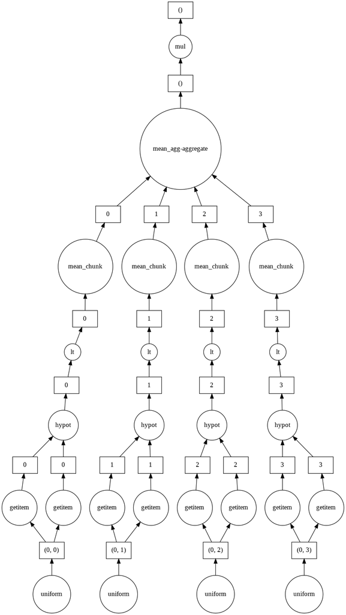

```python
pi.visualize()
```

```python
%timeit estimate_pi_numpy(n=10**7)
```

```
502 ms ± 15.6 ms per loop (mean ± std. dev. of 7 runs, 1 loop each)
```

```python
%timeit pi.compute(scheduler='threads')
```

```
191 ms ± 18.2 ms per loop (mean ± std. dev. of 7 runs, 1 loop each)
```

```python
%timeit pi.compute(scheduler='processes')
```

```
1.54 s ± 69.6 ms per loop (mean ± std. dev. of 7 runs, 1 loop each)
```

### Exercise:

Try timing the NumPy vs Dask threaded vs Dask processes MC simulations.

Try tweaking the `chunks` parameter. How fast can you get it?

```python
# Hint:

import multiprocessing

multiprocessing.cpu_count()
```

```
4
```

### Dask `delayed` decorator

Useful with this pattern:

1. Read in some data
2. Process each item
3. Aggregate those results
4. Report / visualize / etc.

```python
import time
```

```python
def process(item):
    """
    Do some work
    """
    time.sleep(0.2)
    return item*2
```

```python
def aggregate(data):
    return sum([process(item) for item in data])
```

```python
data = list(range(10))
```

```python
data
```

```
[0, 1, 2, 3, 4, 5, 6, 7, 8, 9]
```

```python
result = aggregate(data)
```

```python
result
```

```
90
```

```python
%time aggregate(data)
```

```
CPU times: user 1.85 ms, sys: 569 µs, total: 2.42 ms
Wall time: 2 s
```

```
90
```

```python
from dask import delayed
```

```python
@delayed
def process(item):
    """
    Do some work
    """
    time.sleep(0.2)
    return item*2
```

```python
def aggregate(data):
    return delayed(sum)([process(item) for item in data])
```

```python
result = aggregate(data)
```

```python
%time result.compute()
```

```
CPU times: user 7.6 ms, sys: 1.05 ms, total: 8.65 ms
Wall time: 605 ms
```

```
90
```

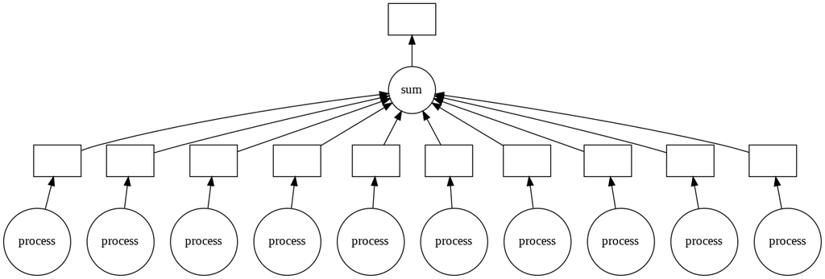

```python
result.visualize()
```

### Instead of parallelizing Pandas code with `delayed`, `dask.dataframe` instead

```python
import dask.dataframe as dd
```

```python
!ls /Data/*.csv
```

```
/Data/abalone.csv			 /Data/gapminderDataFiveYear.csv
/Data/Auto.csv				 /Data/gapminder-health-income.csv
/Data/baby-names.csv			 /Data/heights_and_weights.csv
/Data/bank-small.csv			 /Data/interest_inflation_aud.csv
/Data/basketball.csv			 /Data/LIBOR.csv
/Data/big-mac-full-index.csv		 /Data/melb_monthly_weather_086071.csv
/Data/boston.csv			 /Data/melbourne-temp.csv
/Data/bundoora-temp.csv			 /Data/mushrooms.csv
/Data/calories_clean.csv		 /Data/oecd_stats.csv
/Data/calories.csv			 /Data/olympics2012.csv
/Data/coal_mining_disasters.csv		 /Data/peak_sunlight_hours.csv
/Data/countries.csv			 /Data/public_holidays.csv
/Data/country_populations_by_year.csv	 /Data/sampled_tesla.csv
/Data/darwin-temp.csv			 /Data/study_hours.csv
/Data/eight_schools.csv			 /Data/surnames.csv
/Data/electricity_meter_usage_2017a.csv  /Data/tips.csv
/Data/fed.csv				 /Data/wine.csv
/Data/forbes1964.csv			 /Data/world_bank_countries_data.csv
/Data/forbes.csv
```

```python
import pandas as pd
```

```python
vestas_df = pd.read_parquet('/Data/Vestas_Wind_Stocks.parquet')
vestas_df[:3]
```

|  | Open | High | Low | Close | Volume |
| --- | --- | --- | --- | --- | --- |
| 2007-07-13 | 23.50 | 23.50 | 23.50 | 23.50 | 4679.0 |
| 2007-07-16 | 23.55 | 23.55 | 23.55 | 23.55 | 10016.0 |
| 2007-07-17 | 23.40 | 23.40 | 23.40 | 23.40 | 4464.0 |

```python
vestas_df['Volume'].sum()
```

```
1532229568.0
```

```python
!ls /Data/Vest*
```

```
/Data/Vestas_Wind_Stocks.parquet
```

```python
vestas = dd.read_parquet('/Data/Vestas_Wind_Stocks.parquet', )
```

```python
from dask import compute
```

```python
vestas
```

**Dask DataFrame Structure:**

| npartitions=1 | Open | High | Low | Close | Volume |
| --- | --- | --- | --- | --- | --- |
|  | float64 | float64 | float64 | float64 | float64 |
|  | ... | ... | ... | ... | ... |

Dask Name: read-parquet, 1 tasks

```python
result = vestas['Volume'].sum()
```

```python
result.compute()
```

```
1532229568.0
```

```python
vestas
```

**Dask DataFrame Structure:**

| npartitions=1 | Open | High | Low | Close | Volume |
| --- | --- | --- | --- | --- | --- |
|  | float64 | float64 | float64 | float64 | float64 |
|  | ... | ... | ... | ... | ... |

Dask Name: read-parquet, 1 tasks

### Tip: ensure you have a sorted index if possible for performance

## Question: GPUs

Numba supports GPUs.

You can `delay` Numba functions across a cluster.

## Homework on testing: TDD and property-based testing with `hypothesis`

In the Trainer folder.

```python
from dask.distributed import Client
```

```python
client = Client('192.168.0.150:8786')
```

[output not shown]

[output cut: 29 more lines]

[output not shown]

```python
pi.compute(scheduler=client)
```